# Building Initial Monetary Models

# 1 Load and Configure Datasets

We first want to load some synthetic transaction data.

```r
customer_cohort_tbl <- read_rds("data/synthdata_allfixed_cohort_tbl.rds")
customer_cohort_tbl %>% glimpse()
```

```
## Rows: 50,000
## Columns: 4
## $ customer_id    <chr> "C201901_0001", "C201901_0002", "C201901_0003", "C20190…
## $ cohort_qtr     <chr> "2019 Q1", "2019 Q1", "2019 Q1", "2019 Q1", "2019 Q1", …
## $ cohort_ym      <chr> "2019 01", "2019 01", "2019 01", "2019 01", "2019 01", …
## $ first_tnx_date <date> 2019-01-01, 2019-01-01, 2019-01-01, 2019-01-01, 2019-0…
```

```r
customer_simparams_tbl <- read_rds("data/synthdata_allfixed_simparams_tbl.rds")
customer_simparams_tbl %>% glimpse()
```

```
## Rows: 50,000
## Columns: 9
## $ customer_id     <chr> "C201901_0001", "C201901_0002", "C201901_0003", "C2019…
## $ cohort_qtr      <chr> "2019 Q1", "2019 Q1", "2019 Q1", "2019 Q1", "2019 Q1",…
## $ cohort_ym       <chr> "2019 01", "2019 01", "2019 01", "2019 01", "2019 01",…
## $ first_tnx_date  <date> 2019-01-01, 2019-01-01, 2019-01-01, 2019-01-01, 2019-…
## $ customer_mu     <dbl> 0.07041543, 0.05044251, 0.04131343, 0.06001408, 0.1847…
## $ customer_tau    <dbl> 53, 53, 53, 53, 53, 53, 53, 53, 53, 53, 53, 53, 53, 53…
## $ customer_lambda <dbl> 0.1, 0.1, 0.1, 0.1, 0.1, 0.1, 0.1, 0.1, 0.1, 0.1, 0.1,…
## $ customer_nu     <dbl> 0.59797122, 4.02749754, 0.19434751, 3.30778077, 1.1879…
## $ customer_p      <dbl> 100, 100, 100, 100, 100, 100, 100, 100, 100, 100, 100,…
```

```r
customer_transactions_tbl <- read_rds("data/synthdata_allfixed_transactions_tbl.rds")
customer_transactions_tbl %>% glimpse()
```

```
## Rows: 179,043
## Columns: 5
## $ customer_id   <chr> "C201901_0001", "C201901_0001", "C201901_0001", "C201901…
## $ cohort_qtr    <chr> "2019 Q1", "2019 Q1", "2019 Q1", "2019 Q1", "2019 Q1", "…
## $ cohort_ym     <chr> "2019 01", "2019 01", "2019 01", "2019 01", "2019 01", "…
## $ tnx_timestamp <dttm> 2019-01-01 17:18:06, 2019-02-08 01:32:56, 2019-07-10 03…
## $ tnx_amount    <dbl> 191.88, 158.80, 160.51, 157.93, 135.85, 197.42, 23.02, 2…
```

Our transaction data is our main input data for this work, so we will show the first few rows of this.

```r
customer_transactions_tbl %>% arrange(tnx_timestamp) %>% head(10)
```

```
## # A tibble: 10 × 5
##    customer_id  cohort_qtr cohort_ym tnx_timestamp       tnx_amount
##    <chr>        <chr>      <chr>     <dttm>                   <dbl>
##  1 C201901_0098 2019 Q1    2019 01   2019-01-01 00:02:32       140.
##  2 C201901_0066 2019 Q1    2019 01   2019-01-01 00:03:23      1390.
##  3 C201901_0039 2019 Q1    2019 01   2019-01-01 00:11:23       207.
##  4 C201901_0017 2019 Q1    2019 01   2019-01-01 00:22:12       116.
##  5 C201901_0105 2019 Q1    2019 01   2019-01-01 00:24:23       117.
##  6 C201901_0063 2019 Q1    2019 01   2019-01-01 00:34:58       428.
##  7 C201901_0014 2019 Q1    2019 01   2019-01-01 00:40:01       281.
##  8 C201901_0042 2019 Q1    2019 01   2019-01-01 00:40:36       353.
##  9 C201901_0003 2019 Q1    2019 01   2019-01-01 00:42:04       458.
## 10 C201901_0104 2019 Q1    2019 01   2019-01-01 00:53:29       220.
```

We also want to set up a number of parameters for use in this workbook

```r
stan_modeldir <- "stan_models"
stan_codedir  <-   "stan_code"
```

## 1.1 Construct Visualisation Data

```r
customer_summarystats_tbl <- customer_transactions_tbl %>%
  calculate_transaction_summary_stats()

customer_summarystats_tbl %>% glimpse()
```

```
## Rows: 50,000
## Columns: 9
## $ customer_id  <chr> "C201901_0001", "C201901_0002", "C201901_0003", "C201901_…
## $ tnx_count    <int> 6, 6, 7, 5, 10, 4, 9, 6, 4, 1, 5, 5, 4, 10, 6, 5, 6, 8, 1…
## $ first_tnx_ts <dttm> 2019-01-01 17:18:06, 2019-01-01 02:47:52, 2019-01-01 00:…
## $ last_tnx_ts  <dttm> 2019-12-23 06:58:59, 2019-12-03 07:24:05, 2019-10-15 05:…
## $ btyd_count   <dbl> 5, 5, 6, 4, 9, 3, 8, 5, 3, 0, 4, 4, 3, 9, 5, 4, 5, 7, 9, …
## $ all_weeks    <dbl> 52, 52, 52, 52, 52, 52, 52, 52, 52, 52, 52, 52, 52, 52, 5…
## $ tnx_weeks    <dbl> 50.79572, 48.02740, 41.02669, 14.77388, 51.88295, 28.1065…
## $ obs_freq     <dbl> 0.09843349, 0.10410723, 0.14624625, 0.27074803, 0.1734674…
## $ emp_freq     <dbl> 0.09615385, 0.09615385, 0.11538462, 0.07692308, 0.1730769…
```

We want to view the transactions to get a sense of how regular our transactions are in general.

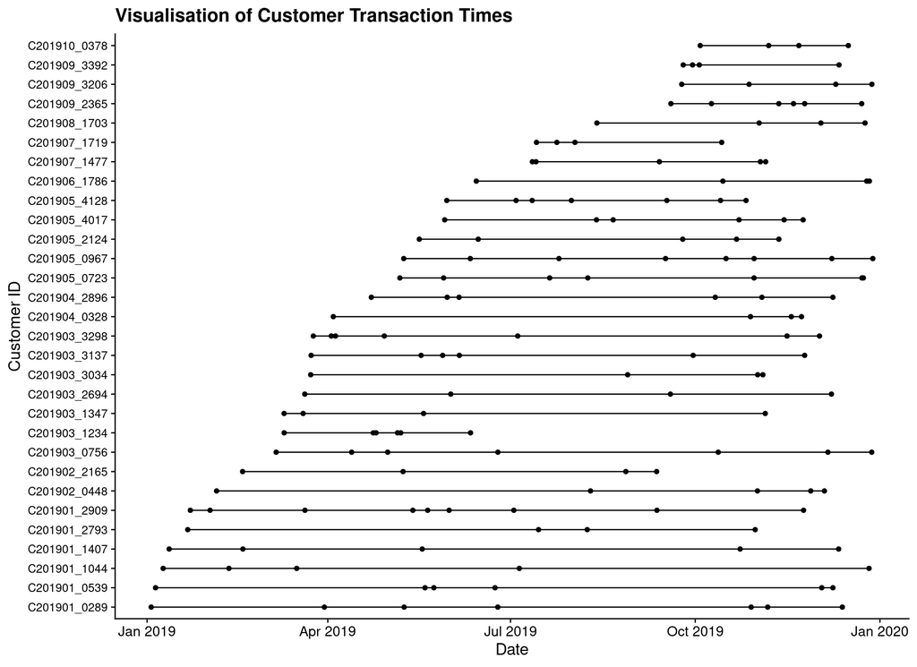

```r
plot_tbl <- customer_transactions_tbl %>%
  group_nest(customer_id, .key = "cust_data") %>%
  filter(map_int(cust_data, nrow) > 3) %>%
  slice_sample(n = 30) %>%
  unnest(cust_data)

ggplot(plot_tbl, aes(x = tnx_timestamp, y = customer_id)) +
  geom_line() +
  geom_point() +
  labs(
    x = "Date",
    y = "Customer ID",
    title = "Visualisation of Customer Transaction Times"
    ) +
  theme(axis.text.y = element_text(size = 10))
```

## 1.2 Construct Data Subsets

For the purposes of saving on time and computation, we construct a subset of the data first, and rather than constructing different samples each time we instead construct sets of `customer_id` to draw upon, then using those list of values when we want to take a subset.

We do this by randomly shuffling the data and then selecting the top $n$ values of `customer_id`.

```r
shuffle_tbl <- customer_summarystats_tbl %>%
  slice_sample(prop = 1, replace = FALSE)

id_1000  <- shuffle_tbl %>% head(1000)  %>% pull(customer_id) %>% sort()
id_5000  <- shuffle_tbl %>% head(5000)  %>% pull(customer_id) %>% sort()
id_10000 <- shuffle_tbl %>% head(10000) %>% pull(customer_id) %>% sort()
```

We now have a list of `customer_id` values we use to subset the data.

# 2 Fit Transaction Amount Models

We first want to use these samples of the dataset to look at it.

```r
fit_1000_data_tbl <- customer_transactions_tbl %>%
  filter(customer_id %in% id_1000)

fit_1000_data_tbl %>% glimpse()
```

```
## Rows: 3,556
## Columns: 5
## $ customer_id   <chr> "C201901_0025", "C201901_0084", "C201901_0084", "C201901…
## $ cohort_qtr    <chr> "2019 Q1", "2019 Q1", "2019 Q1", "2019 Q1", "2019 Q1", "…
## $ cohort_ym     <chr> "2019 01", "2019 01", "2019 01", "2019 01", "2019 01", "…
## $ tnx_timestamp <dttm> 2019-01-01 04:00:15, 2019-01-01 08:39:04, 2019-01-07 20…
## $ tnx_amount    <dbl> 68.62, 69.93, 77.09, 84.40, 74.79, 83.76, 78.96, 65.58, …
```

```r
fit_10000_data_tbl <- customer_transactions_tbl %>%
  filter(customer_id %in% id_10000)

fit_10000_data_tbl %>% glimpse()
```

```
## Rows: 35,972
## Columns: 5
## $ customer_id   <chr> "C201901_0002", "C201901_0002", "C201901_0002", "C201901…
## $ cohort_qtr    <chr> "2019 Q1", "2019 Q1", "2019 Q1", "2019 Q1", "2019 Q1", "…
## $ cohort_ym     <chr> "2019 01", "2019 01", "2019 01", "2019 01", "2019 01", "…
## $ tnx_timestamp <dttm> 2019-01-01 02:47:52, 2019-02-01 02:21:10, 2019-04-28 18…
## $ tnx_amount    <dbl> 23.02, 22.42, 30.02, 28.29, 25.66, 26.07, 46.25, 39.93, …
```

## 2.1 Fit Initial Flat Stan Model

```
## data {
##   real<lower=0> p;                // parameter 1 for Gamma top level
##   real<lower=0> q;                // parameter q for Gamma nu draw
##   real<lower=0> g;                // parameter g for Gamma nu draw
##
##   int<lower=1> n;                    // count of transactions
##   int<lower=1> n_customer_id;        // count of customers
##
##   array[n] int<lower=0> customer_id; // index for customer
##
##   vector<lower=0>[n] tnx_amt;        // transaction amount
## }
##
## parameters {
##   vector<lower=0>[n_customer_id] nu;
## }
##
## model {
##   nu ~ gamma(q, g);
##
##   for(i in 1:n) {
##     tnx_amt[i] ~ gamma(p, nu[customer_id[i]]);
##   }
## }
##
## generated quantities {
##   vector[n] log_lik;
##
##   for (i in 1:n) {
##     log_lik[i] = gamma_lpdf(tnx_amt[i] | p, nu[customer_id[i]]);
##   }
## }
```

We now compile this model using `CmdStanR`.

```r
amtmodel_flat_stanmodel <- cmdstan_model(
  "stan_code/amtmodel_flat.stan",
  include_paths =   stan_codedir,
  pedantic      =           TRUE,
  dir           =  stan_modeldir
  )
```

We then use this compiled model with our data to produce a fit of the data.

```r
stan_modelname <- "amtmodel_flat"
stanfit_prefix <- str_c("fit_", stan_modelname)

stan_data_lst <- fit_1000_data_tbl %>%
  select(customer_id, tnx_amt = tnx_amount) %>%
  compose_data(
    p  =  100,
    q =     1,
    g =     1
    )

amtmodel_flat_stanfit <- amtmodel_flat_stanmodel$sample(
  data            =                stan_data_lst,
  chains          =                            4,
  iter_warmup     =                          500,
  iter_sampling   =                          500,
  seed            =                         4201,
  save_warmup     =                         TRUE,
  output_dir      =                stan_modeldir,
  output_basename =               stanfit_prefix,
  )
```

```
## Running MCMC with 4 parallel chains...
##
## Chain 1 Iteration:   1 / 1000 [  0%]  (Warmup)
## Chain 2 Iteration:   1 / 1000 [  0%]  (Warmup)
## Chain 3 Iteration:   1 / 1000 [  0%]  (Warmup)
## Chain 4 Iteration:   1 / 1000 [  0%]  (Warmup)
## Chain 1 Iteration: 100 / 1000 [ 10%]  (Warmup)
## Chain 2 Iteration: 100 / 1000 [ 10%]  (Warmup)
## Chain 3 Iteration: 100 / 1000 [ 10%]  (Warmup)
## Chain 4 Iteration: 100 / 1000 [ 10%]  (Warmup)
## Chain 1 Iteration: 200 / 1000 [ 20%]  (Warmup)
## Chain 2 Iteration: 200 / 1000 [ 20%]  (Warmup)
## Chain 3 Iteration: 200 / 1000 [ 20%]  (Warmup)
## Chain 4 Iteration: 200 / 1000 [ 20%]  (Warmup)
## Chain 2 Iteration: 300 / 1000 [ 30%]  (Warmup)
## Chain 1 Iteration: 300 / 1000 [ 30%]  (Warmup)
## Chain 3 Iteration: 300 / 1000 [ 30%]  (Warmup)
## Chain 4 Iteration: 300 / 1000 [ 30%]  (Warmup)
## Chain 2 Iteration: 400 / 1000 [ 40%]  (Warmup)
## Chain 1 Iteration: 400 / 1000 [ 40%]  (Warmup)
## Chain 3 Iteration: 400 / 1000 [ 40%]  (Warmup)
## Chain 4 Iteration: 400 / 1000 [ 40%]  (Warmup)
## Chain 2 Iteration: 500 / 1000 [ 50%]  (Warmup)
## Chain 2 Iteration: 501 / 1000 [ 50%]  (Sampling)
## Chain 1 Iteration: 500 / 1000 [ 50%]  (Warmup)
## Chain 1 Iteration: 501 / 1000 [ 50%]  (Sampling)
## Chain 3 Iteration: 500 / 1000 [ 50%]  (Warmup)
## Chain 3 Iteration: 501 / 1000 [ 50%]  (Sampling)
## Chain 4 Iteration: 500 / 1000 [ 50%]  (Warmup)
## Chain 4 Iteration: 501 / 1000 [ 50%]  (Sampling)
## Chain 2 Iteration: 600 / 1000 [ 60%]  (Sampling)
## Chain 1 Iteration: 600 / 1000 [ 60%]  (Sampling)
## Chain 4 Iteration: 600 / 1000 [ 60%]  (Sampling)
## Chain 3 Iteration: 600 / 1000 [ 60%]  (Sampling)
## Chain 2 Iteration: 700 / 1000 [ 70%]  (Sampling)
## Chain 1 Iteration: 700 / 1000 [ 70%]  (Sampling)
## Chain 3 Iteration: 700 / 1000 [ 70%]  (Sampling)
## Chain 4 Iteration: 700 / 1000 [ 70%]  (Sampling)
## Chain 2 Iteration: 800 / 1000 [ 80%]  (Sampling)
## Chain 1 Iteration: 800 / 1000 [ 80%]  (Sampling)
## Chain 4 Iteration: 800 / 1000 [ 80%]  (Sampling)
## Chain 3 Iteration: 800 / 1000 [ 80%]  (Sampling)
## Chain 2 Iteration: 900 / 1000 [ 90%]  (Sampling)
## Chain 1 Iteration: 900 / 1000 [ 90%]  (Sampling)
## Chain 3 Iteration: 900 / 1000 [ 90%]  (Sampling)
## Chain 4 Iteration: 900 / 1000 [ 90%]  (Sampling)
## Chain 2 Iteration: 1000 / 1000 [100%]  (Sampling)
## Chain 2 finished in 11.0 seconds.
## Chain 1 Iteration: 1000 / 1000 [100%]  (Sampling)
## Chain 1 finished in 11.3 seconds.
## Chain 4 Iteration: 1000 / 1000 [100%]  (Sampling)
## Chain 4 finished in 11.0 seconds.
## Chain 3 Iteration: 1000 / 1000 [100%]  (Sampling)
## Chain 3 finished in 11.2 seconds.
##
## All 4 chains finished successfully.
## Mean chain execution time: 11.1 seconds.
## Total execution time: 11.8 seconds.
```

```r
amtmodel_flat_stanfit$summary()
```

```
## # A tibble: 4,557 × 10
##    variable       mean   median      sd     mad       q5      q95  rhat ess_bulk
##    <chr>         <dbl>    <dbl>   <dbl>   <dbl>    <dbl>    <dbl> <dbl>    <dbl>
##  1 lp__       -5.41e+5 -5.41e+5 2.22e+1 2.22e+1 -5.41e+5 -5.41e+5  1.01     642.
##  2 nu[1]       1.45e+0  1.44e+0 1.40e-1 1.42e-1  1.23e+0  1.69e+0  1.00    3190.
##  3 nu[2]       1.32e+0  1.32e+0 4.39e-2 4.42e-2  1.25e+0  1.40e+0  1.01    4330.
##  4 nu[3]       1.01e-1  1.01e-1 3.93e-3 3.79e-3  9.45e-2  1.07e-1  1.00    2308.
##  5 nu[4]       3.49e-1  3.49e-1 1.16e-2 1.12e-2  3.30e-1  3.68e-1  1.00    3094.
##  6 nu[5]       1.21e+0  1.21e+0 3.53e-2 3.45e-2  1.15e+0  1.27e+0  1.00    4167.
##  7 nu[6]       7.67e-2  7.67e-2 2.90e-3 2.87e-3  7.21e-2  8.15e-2  1.00    3199.
##  8 nu[7]       7.42e-2  7.41e-2 5.20e-3 5.23e-3  6.58e-2  8.32e-2  1.00    3989.
##  9 nu[8]       7.07e-1  7.08e-1 2.36e-2 2.37e-2  6.68e-1  7.46e-1  1.00    4385.
## 10 nu[9]       2.40e+0  2.40e+0 1.21e-1 1.22e-1  2.21e+0  2.60e+0  1.01    3755.
## # … with 4,547 more rows, and 1 more variable: ess_tail <dbl>
```

We first want to check the HMC diagnostics.

```r
amtmodel_flat_stanfit$cmdstan_diagnose()
```

```
## Processing csv files: /home/rstudio/workshop/stan_models/fit_amtmodel_flat-1.csvWarning: non-fatal error reading adaptation data
## , /home/rstudio/workshop/stan_models/fit_amtmodel_flat-2.csvWarning: non-fatal error reading adaptation data
## , /home/rstudio/workshop/stan_models/fit_amtmodel_flat-3.csvWarning: non-fatal error reading adaptation data
## , /home/rstudio/workshop/stan_models/fit_amtmodel_flat-4.csvWarning: non-fatal error reading adaptation data
##
##
## Checking sampler transitions treedepth.
## Treedepth satisfactory for all transitions.
##
## Checking sampler transitions for divergences.
## No divergent transitions found.
##
## Checking E-BFMI - sampler transitions HMC potential energy.
## E-BFMI satisfactory.
##
## Effective sample size satisfactory.
##
## Split R-hat values satisfactory all parameters.
##
## Processing complete, no problems detected.
```

### 2.1.1 Visual Diagnostics of the Sample Validity

Now that we have a sample from the posterior distribution we need to create a few different visualisations of the diagnostics.

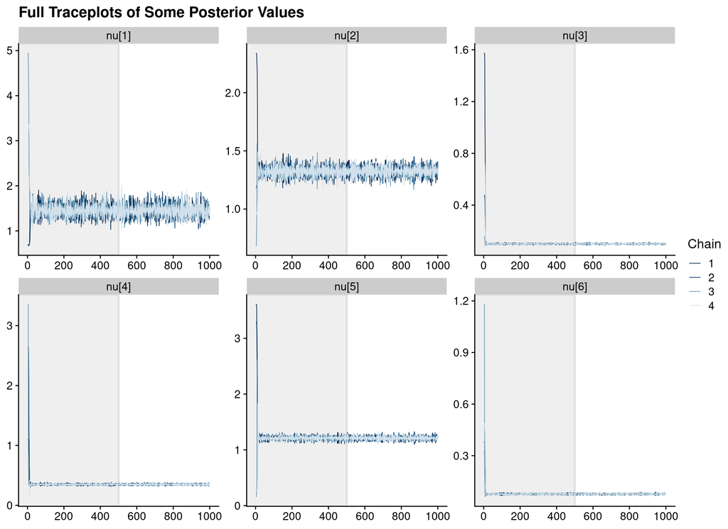

```r
parameter_subset <- c(
  "nu[1]", "nu[2]", "nu[3]", "nu[4]", "nu[5]", "nu[6]"
  )

amtmodel_flat_stanfit$draws(inc_warmup = TRUE) %>%
  mcmc_trace(
    pars     = parameter_subset,
    n_warmup = 500
    ) +
  ggtitle("Full Traceplots of Some Posterior Values")
```

As the warmup is skewing the y-axis somewhat, we repeat this process without the warmup.

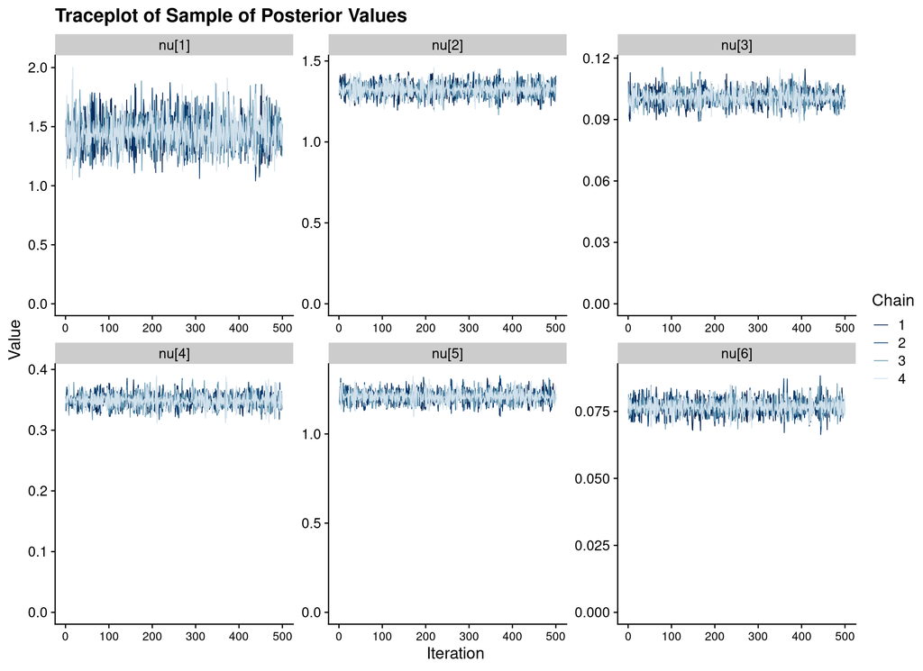

```r
amtmodel_flat_stanfit$draws(inc_warmup = FALSE) %>%
  mcmc_trace(
    pars     = parameter_subset
    ) +
  expand_limits(y = 0) +
  labs(
    x = "Iteration",
    y = "Value",
    title = "Traceplot of Sample of Posterior Values"
    ) +
  theme(axis.text.x = element_text(size = 10))
```

A common MCMC diagnostic is $\hat{R}$ - which is a measure of the ‘similarity’ of the chains.

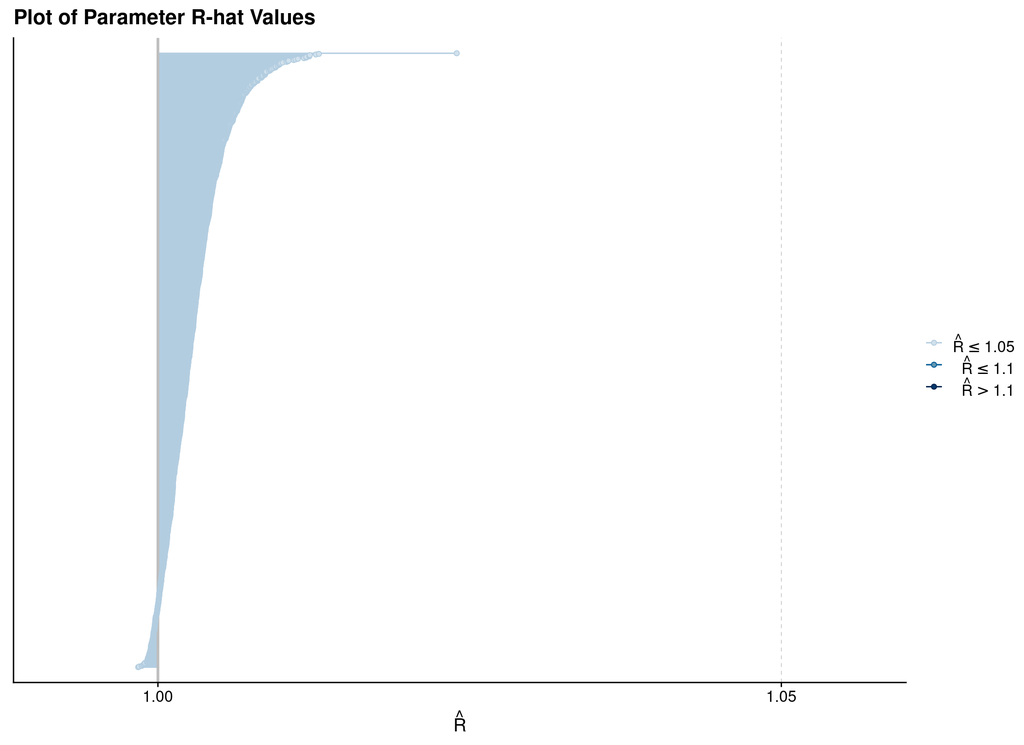

```r
amtmodel_flat_stanfit %>%
  rhat(pars = c("nu")) %>%
  mcmc_rhat() +
    ggtitle("Plot of Parameter R-hat Values")
```

Related to this quantity is the concept of *effective sample size*, $N_{eff}$, an estimate of the size of the sample from a statistical information point of view.

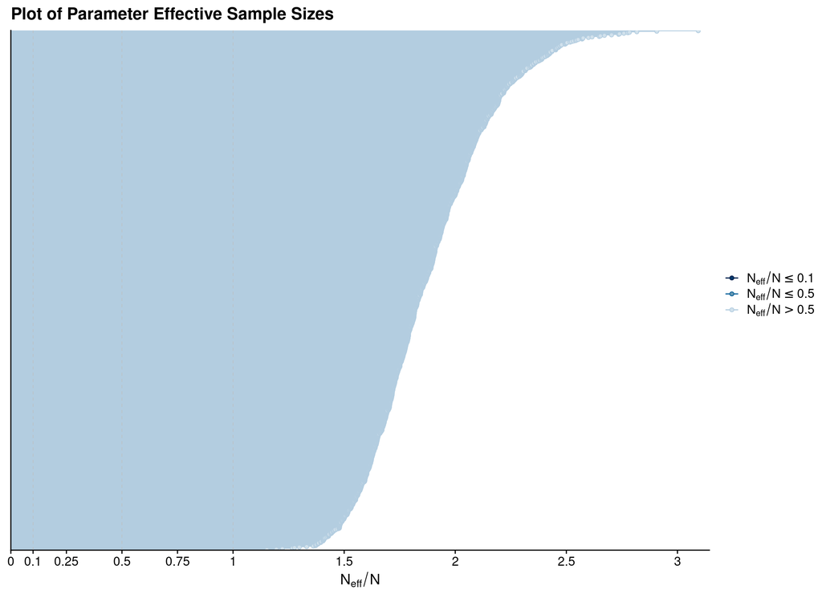

```r
amtmodel_flat_stanfit %>%
  neff_ratio(pars = c("nu")) %>%
  mcmc_neff() +
    ggtitle("Plot of Parameter Effective Sample Sizes")
```

Finally, we also want to look at autocorrelation in the chains for each parameter.

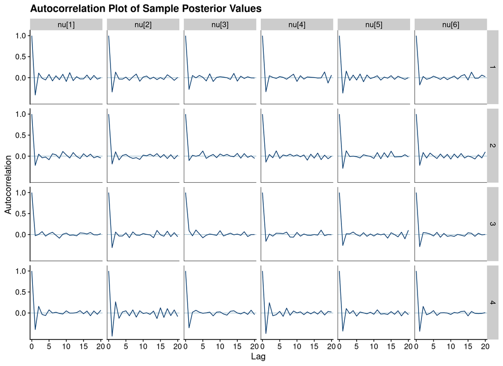

```r
amtmodel_flat_stanfit$draws() %>%
  mcmc_acf(pars = parameter_subset) +
    ggtitle("Autocorrelation Plot of Sample Posterior Values")
```

In practice we do not always require a comprehensive exploration of the diagnostics, but it is good practice to run through the various visualisations when we fit a model to ensure our sample is valid.

## 2.2 Check Model Fit

We now need to check the parameters of this fit against the data to see how effective our model is at capturing the data. In this case we have the benefit of knowing the ‘true’ data, and so we compare our model output against the input parameters.

```r
amtmodel_flat_validation_tbl <- amtmodel_flat_stanfit %>%
  recover_types(fit_1000_data_tbl) %>%
  spread_draws(nu[customer_id]) %>%
  ungroup() %>%
  inner_join(
    customer_summarystats_tbl %>% select(customer_id, tnx_count),
    by = "customer_id"
    ) %>%
  inner_join(customer_simparams_tbl, by = "customer_id") %>%
  select(
    customer_id, draw_id = .draw, tnx_count,
    post_nu = nu, customer_p, customer_nu
    )

amtmodel_flat_validation_tbl %>% glimpse()
```

```
## Rows: 2,000,000
## Columns: 6
## $ customer_id <chr> "C201901_0025", "C201901_0025", "C201901_0025", "C201901_0…
## $ draw_id     <int> 1, 2, 3, 4, 5, 6, 7, 8, 9, 10, 11, 12, 13, 14, 15, 16, 17,…
## $ tnx_count   <int> 1, 1, 1, 1, 1, 1, 1, 1, 1, 1, 1, 1, 1, 1, 1, 1, 1, 1, 1, 1…
## $ post_nu     <dbl> 1.41266, 1.46895, 1.47528, 1.34603, 1.53986, 1.37628, 1.58…
## $ customer_p  <dbl> 100, 100, 100, 100, 100, 100, 100, 100, 100, 100, 100, 100…
## $ customer_nu <dbl> 1.546918, 1.546918, 1.546918, 1.546918, 1.546918, 1.546918…
```

Having constructed the validation data we now want to check the quantile of each ‘true’ value in the posterior distribution for the parameter. If our model is valid, this distribution will be uniform on $[0, 1]$.

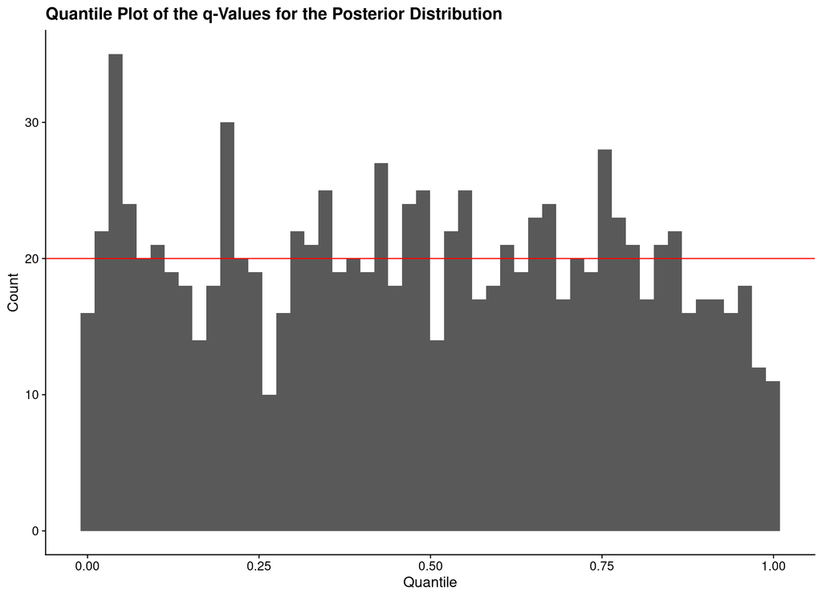

```r
amtmodel_flat_nu_qvalues_tbl <- amtmodel_flat_validation_tbl %>%
  calculate_distribution_qvals(post_nu, customer_nu, customer_id)

ref_value <- amtmodel_flat_nu_qvalues_tbl %>% nrow() %>% divide_by(50)

ggplot(amtmodel_flat_nu_qvalues_tbl) +
  geom_histogram(aes(x = q_val), bins = 50) +
  geom_hline(aes(yintercept = ref_value), colour = "red") +
  labs(
    x = "Quantile",
    y = "Count",
    title = "Quantile Plot of the q-Values for the Posterior Distribution"
    )
```

[figure not shown]

```r
ggplot(amtmodel_flat_nu_qvalues_tbl) +
  geom_point(aes(x = q_val, y = customer_nu)) +
  labs(
    x = "Quantile",
    y = "Customer p",
    title = "Scatterplot of q-Value against p"
    )
```

In real world examples we will not have any “true” parameter values though, so we also want to look at the distribution of $q$-values against the derived ECDFs:

```r
amtmodel_flat_amt_qvals_tbl <-  fit_1000_data_tbl %>%
  group_by(customer_id) %>%
  summarise(
    .groups = "drop",

    tnx_vals = list(tnx_amount)
    ) %>%
  inner_join(
    amtmodel_flat_validation_tbl %>% select(customer_id, customer_p, post_nu),
    by = "customer_id"
    ) %>%
  mutate(
    q_vals = pmap(
      list(x1 = tnx_vals, x2 = customer_p, x3 = post_nu),
      function(x1, x2, x3) pgamma(q = x1, shape = x2, rate = x3)
      )
    ) %>%
  select(customer_id, customer_p, post_nu, q_vals) %>%
  unnest(q_vals)

amtmodel_flat_amt_qvals_tbl %>% glimpse()
```

```
## Rows: 7,112,000
## Columns: 4
## $ customer_id <chr> "C201901_0025", "C201901_0025", "C201901_0025", "C201901_0…
## $ customer_p  <dbl> 100, 100, 100, 100, 100, 100, 100, 100, 100, 100, 100, 100…
## $ post_nu     <dbl> 1.41266, 1.46895, 1.47528, 1.34603, 1.53986, 1.37628, 1.58…
## $ q_vals      <dbl> 0.39124142, 0.54500141, 0.56205240, 0.22652759, 0.72218614…
```

# 3 R Environment

```r
options(width = 120L)
```

```r
options(width = 80L)
```